# Anàlisi de Framing: Catalunya al Parlament d’Andalusia

Published

April 24, 2026

## Sobre les dades

1. **Detecció per regex** (`4_analisi_descriptiu.qmd`) — identifica totes les intervencions que contenen el patró `REGEX_CATALUNYA_EXT` (topònim, gentilici, independentisme, separatisme, *golpistas*).
2. **Classificació LLM** (`5_llm_framing.R`) — per a cada intervenció detectada, un model OpenAI aplica el codebook de *framing* estructurat i retorna `sentiment_cat` i `primary_frame` en JSON Schema garantit.

Table 1: Estat del corpus en el moment de renderitzar

| Indicador | Valor |
| --- | --- |
| Intervencions totals al corpus | 9.942 |
| Intervencions amb menció a Catalunya (regex ampliat) | 792 |
| — classificades pel LLM | 792 |
| — pendents de classificació | 0 |

> Les seccions d’anàlisi LLM s’actualitzen automàticament en re-renderitzar, a mesura que `5_llm_framing.R` classifica noves intervencions.

## Part 1: Visió general de les mencions

### Estadístiques globals

```r
tibble(
  Indicador = c(
    "Sessions amb almenys una menció",
    "Intervencions amb menció (% sobre total)",
    "Total de coincidències regex",
    "Oradors únics que mencionen Catalunya",
    "Partits representats"
  ),
  Valor = c(
    as.character(n_distinct(corpus_cat$id_master)),
    paste0(formatC(nrow(corpus_cat), format="fg", big.mark="."),
           "  (", round(100*nrow(corpus_cat)/nrow(corpus), 1), "%)"),
    formatC(sum(corpus$n_mencions_cat_ext, na.rm=TRUE), format="fg", big.mark="."),
    as.character(n_distinct(corpus_cat$orador)),
    as.character(n_distinct(corpus_cat$partit[!is.na(corpus_cat$partit)]))
  )
) |>
  kable(align=c("l","r")) |>
  kable_styling(bootstrap_options=c("striped","hover"),
                full_width=FALSE, position="left")
```

Table 2: Resum de mencions a Catalunya

| Indicador | Valor |
| --- | --- |
| Sessions amb almenys una menció | 93 |
| Intervencions amb menció (% sobre total) | 792 (8%) |
| Total de coincidències regex | 2.079 |
| Oradors únics que mencionen Catalunya | 109 |
| Partits representats | 5 |

### Evolució temporal

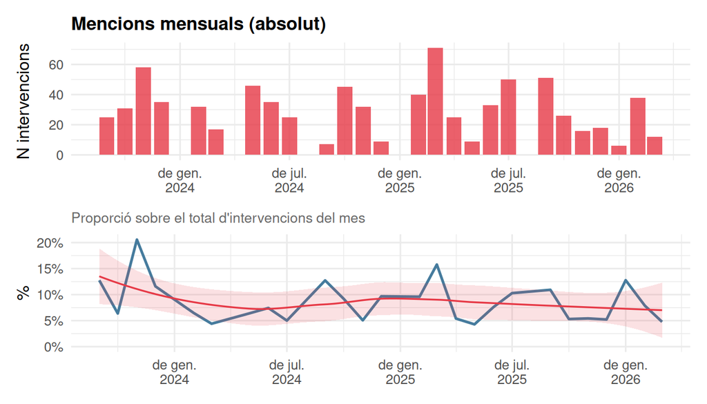

Figure 1: Mencions a Catalunya: absoluts i proporció mensual

```r
cat_mes <- corpus |>
  filter(!is.na(data_mes)) |>
  group_by(data_mes) |>
  summarise(n_total=n(), n_cat=sum(mencio_cat_ext, na.rm=TRUE),
            pct=100*n_cat/n_total, .groups="drop")

p1 <- ggplot(cat_mes, aes(data_mes, n_cat)) +
  geom_col(fill="#E63946", alpha=0.8) +
  scale_x_date(date_breaks="6 months", date_labels="%b\n%Y") +
  labs(title="Mencions mensuals (absolut)", x=NULL, y="N intervencions")

p2 <- ggplot(cat_mes, aes(data_mes, pct)) +
  geom_line(color="#457B9D", linewidth=0.9) +
  geom_smooth(method="loess", se=TRUE, color="#E63946",
              fill="#E63946", alpha=0.15, linewidth=0.6) +
  scale_x_date(date_breaks="6 months", date_labels="%b\n%Y") +
  scale_y_continuous(labels=label_percent(scale=1), limits=c(0,NA)) +
  labs(subtitle="Proporció sobre el total d'intervencions del mes", x=NULL, y="%")

p1 / p2
```

### Per partit al llarg del temps

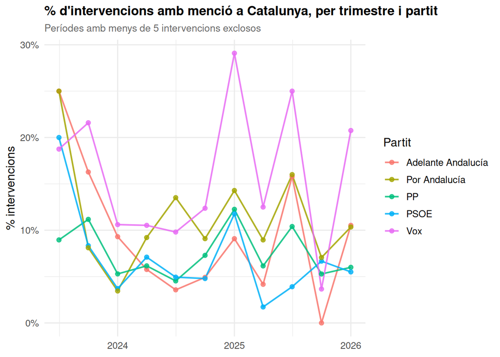

Figure 2: % d’intervencions amb menció a Catalunya per trimestre i partit

```r
corpus |>
  filter(!is.na(partit), !is.na(data_trim)) |>
  group_by(data_trim, partit) |>
  summarise(n_tot=n(), n_cat=sum(mencio_cat_ext, na.rm=TRUE),
            pct=100*n_cat/n_tot, .groups="drop") |>
  filter(n_tot >= 5) |>
  ggplot(aes(data_trim, pct, color=partit)) +
  geom_line(linewidth=0.75, alpha=0.85) +
  geom_point(size=1.8, alpha=0.8) +
  scale_x_date(date_breaks="1 year", date_labels="%Y") +
  scale_y_continuous(labels=label_percent(scale=1), limits=c(0,NA)) +
  labs(title="% d'intervencions amb menció a Catalunya, per trimestre i partit",
       subtitle="Períodes amb menys de 5 intervencions exclosos",
       x=NULL, y="% intervencions", color="Partit") +
  theme(legend.position="right")
```

### Proporció per partit

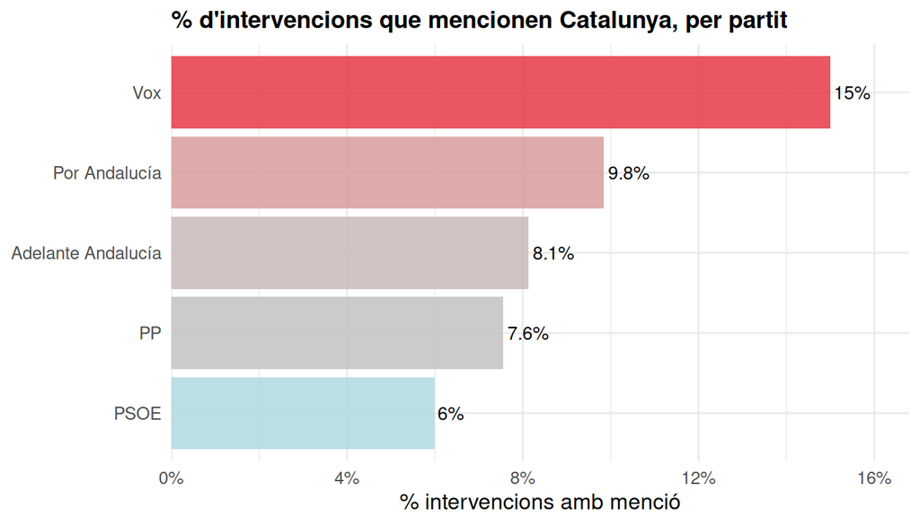

Figure 3: % d’intervencions amb menció a Catalunya per partit

```r
corpus |>
  filter(!is.na(partit)) |>
  group_by(partit) |>
  summarise(pct=100*mean(mencio_cat_ext, na.rm=TRUE), n=n(), .groups="drop") |>
  mutate(partit=fct_reorder(partit, pct), label=paste0(round(pct,1),"%")) |>
  ggplot(aes(pct, partit)) +
  geom_col(aes(fill=pct), alpha=0.85, show.legend=FALSE) +
  geom_text(aes(label=label), hjust=-0.1, size=3.5) +
  scale_fill_gradient(low="#AED9E0", high="#E63946") +
  scale_x_continuous(labels=label_percent(scale=1),
                     expand=expansion(mult=c(0,0.12))) +
  labs(title="% d'intervencions que mencionen Catalunya, per partit",
       x="% intervencions amb menció", y=NULL)
```

## Part 2: Codebook de framing

El codebook segueix la metodologia de **Halterman & Keith (2024)** per a classificació de *frames* discursius amb LLM. Cada intervenció classificada rep dues etiquetes:

### Dimensió 1 — Sentiment (`sentiment_cat`)

| Etiqueta | Definició | Indicadors típics |
| --- | --- | --- |
| **Hostil_Negatiu** | Llenguatge pejoratiu, agressiu o d’alarma | *golpistas, chantaje, ruptura, privilegios* |
| **Neutral_Institucional** | Fets objectius, dades o procediments sense càrrega valorativa | *según los datos, el acuerdo prevé* |
| **Empàtic_Positiu** | Solidaritat, Catalunya com a exemple, crida al diàleg | *ejemplo a seguir, colaboración, entendimiento* |

### Dimensió 2 — Marc discursiu (`primary_frame`)

| Etiqueta | Definició | Regla d’exclusió |
| --- | --- | --- |
| **Grievance_Economics** | Andalusia infrafinançada per concessions a Catalunya | Exclou si no hi ha comparació directa amb Andalusia |
| **Constitutional_Threat** | Catalunya com amenaça a la unitat d’Espanya o l’Estat de Dret | Exclou si la crítica és exclusivament econòmica |
| **Electoral_Weaponization** | Pactes amb partits catalans per atacar un rival polític nacional | Ha d’incloure atac explícit a un partit estatal |
| **Positive_Reference** | Catalunya com a model de bona pràctica o referent d’èxit | Exclou mencions positives purament electoralistes |
| **Other** | Mencions que no encaixen en cap marc anterior | — |

## Part 3: Sentiment

### Global per partit

```r
corpus_llm |>
  filter(!is.na(partit)) |>
  group_by(Partit=partit) |>
  summarise(
    N          = n(),
    Hostil     = sum(llm_sentiment_cat=="Hostil_Negatiu"),
    Neutral    = sum(llm_sentiment_cat=="Neutral_Institucional"),
    Empàtic    = sum(llm_sentiment_cat=="Empàtic_Positiu"),
    `% Hostil` = round(100*Hostil/N, 1),
    `% Neutral`= round(100*Neutral/N, 1),
    `% Empàtic`= round(100*Empàtic/N, 1),
    .groups="drop"
  ) |>
  arrange(desc(`% Hostil`)) |>
  kable(align=c("l",rep("r",7))) |>
  kable_styling(bootstrap_options=c("striped","hover"),
                full_width=FALSE, position="left")
```

Table 3: Distribució de sentiment per partit (N absoluts i % sobre classificades)

| Partit | N | Hostil | Neutral | Empàtic | % Hostil | % Neutral | % Empàtic |
| --- | --- | --- | --- | --- | --- | --- | --- |
| Vox | 112 | 96 | 14 | 2 | 85.7 | 12.5 | 1.8 |
| PP | 490 | 385 | 103 | 2 | 78.6 | 21.0 | 0.4 |
| Por Andalucía | 64 | 6 | 49 | 9 | 9.4 | 76.6 | 14.1 |
| Adelante Andalucía | 30 | 2 | 25 | 3 | 6.7 | 83.3 | 10.0 |
| PSOE | 82 | 5 | 56 | 21 | 6.1 | 68.3 | 25.6 |

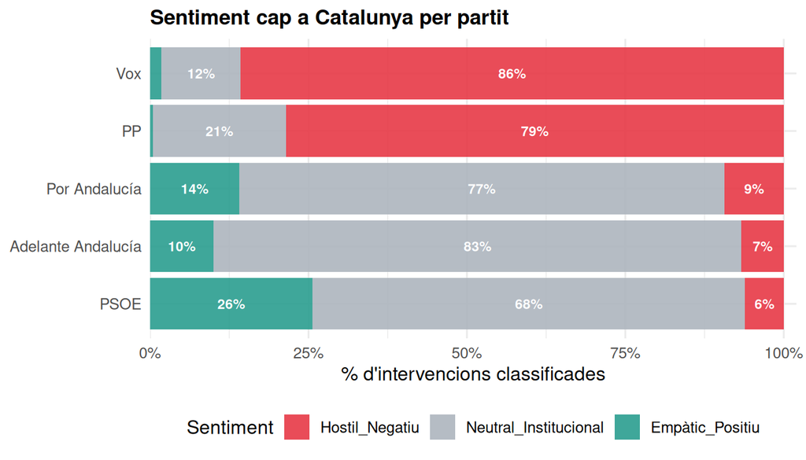

Figure 4: Distribució de sentiment per partit (% sobre intervencions classificades)

```r
corpus_llm |>
  filter(!is.na(partit)) |>
  count(partit, llm_sentiment_cat) |>
  group_by(partit) |>
  mutate(pct=100*n/sum(n)) |>
  ungroup() |>
  mutate(
    partit = fct_reorder(
      partit,
      ifelse(llm_sentiment_cat=="Hostil_Negatiu", pct, 0),
      .fun=sum, .na_rm=TRUE
    ),
    llm_sentiment_cat = factor(llm_sentiment_cat,
      levels=c("Hostil_Negatiu","Neutral_Institucional","Empàtic_Positiu"))
  ) |>
  ggplot(aes(pct, partit, fill=llm_sentiment_cat)) +
  geom_col(position="stack", alpha=0.9) +
  geom_text(aes(label=if_else(pct>6, paste0(round(pct),"%"), "")),
            position=position_stack(vjust=0.5), size=3, color="white", fontface="bold") +
  scale_fill_manual(values=COL_SENTIMENT, name="Sentiment") +
  scale_x_continuous(labels=label_percent(scale=1),
                     expand=expansion(mult=c(0,0.02))) +
  labs(title="Sentiment cap a Catalunya per partit",
       x="% d'intervencions classificades", y=NULL)
```

### Evolució temporal del sentiment per partit

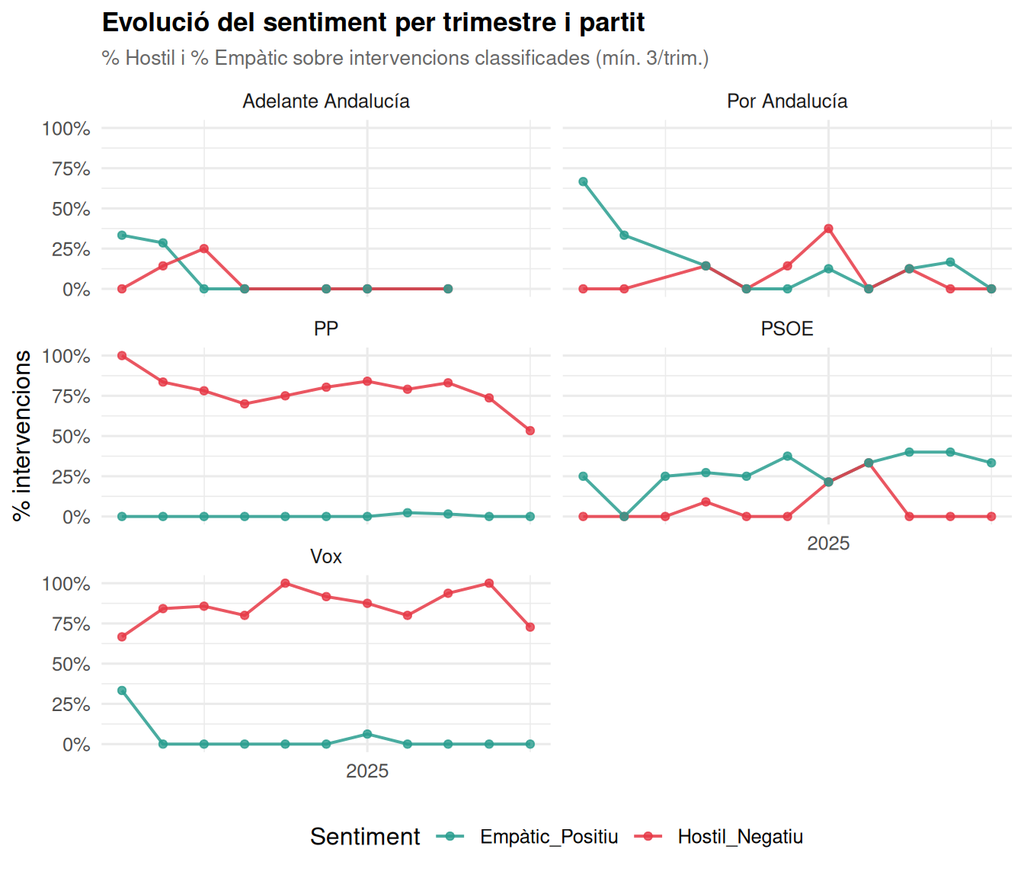

Figure 5: Evolució del sentiment per trimestre i partit

```r
corpus_llm |>
  filter(!is.na(partit), !is.na(data_trim)) |>
  group_by(data_trim, partit) |>
  summarise(
    n_tot    = n(),
    pct_host = 100*mean(llm_sentiment_cat=="Hostil_Negatiu"),
    pct_emp  = 100*mean(llm_sentiment_cat=="Empàtic_Positiu"),
    .groups  = "drop"
  ) |>
  filter(n_tot >= 3) |>
  pivot_longer(c(pct_host, pct_emp), names_to="sentiment", values_to="pct") |>
  mutate(sentiment = recode(sentiment,
    pct_host="Hostil_Negatiu", pct_emp="Empàtic_Positiu")) |>
  ggplot(aes(data_trim, pct, color=sentiment,
             group=interaction(partit, sentiment))) +
  geom_line(linewidth=0.7, alpha=0.85) +
  geom_point(size=1.5, alpha=0.8) +
  facet_wrap(~partit, ncol=2) +
  scale_color_manual(
    values=COL_SENTIMENT[c("Hostil_Negatiu","Empàtic_Positiu")],
    name="Sentiment") +
  scale_x_date(date_breaks="2 years", date_labels="%Y") +
  scale_y_continuous(labels=label_percent(scale=1), limits=c(0,NA)) +
  labs(title="Evolució del sentiment per trimestre i partit",
       subtitle="% Hostil i % Empàtic sobre intervencions classificades (mín. 3/trim.)",
       x=NULL, y="% intervencions")
```

## Part 4: Marc discursiu

### Global per partit

```r
corpus_llm |>
  filter(!is.na(partit)) |>
  count(Partit=partit, frame=llm_primary_frame) |>
  group_by(Partit) |>
  mutate(pct=round(100*n/sum(n),1), N=sum(n)) |>
  ungroup() |>
  pivot_wider(id_cols=c(Partit,N), names_from=frame,
              values_from=pct, values_fill=0) |>
  select(Partit, N, any_of(FRAME_LVLS)) |>
  arrange(desc(
    rowSums(across(any_of(c("Constitutional_Threat","Electoral_Weaponization")),
                   \(x) replace_na(x, 0)))
  )) |>
  kable(align=c("l","r",rep("r",5))) |>
  kable_styling(bootstrap_options=c("striped","hover"),
                full_width=FALSE, position="left")
```

Table 4: Distribució de frames per partit (% sobre intervencions classificades)

| Partit | N | Constitutional_Threat | Electoral_Weaponization | Grievance_Economics | Positive_Reference | Other |
| --- | --- | --- | --- | --- | --- | --- |
| Vox | 112 | 31.2 | 50.0 | 1.8 | 1.8 | 15.2 |
| PP | 490 | 9.0 | 50.0 | 25.9 | 0.2 | 14.9 |
| Adelante Andalucía | 30 | 3.3 | 30.0 | 26.7 | 0.0 | 40.0 |
| PSOE | 82 | 0.0 | 29.3 | 3.7 | 13.4 | 53.7 |
| Por Andalucía | 64 | 0.0 | 23.4 | 6.2 | 9.4 | 60.9 |

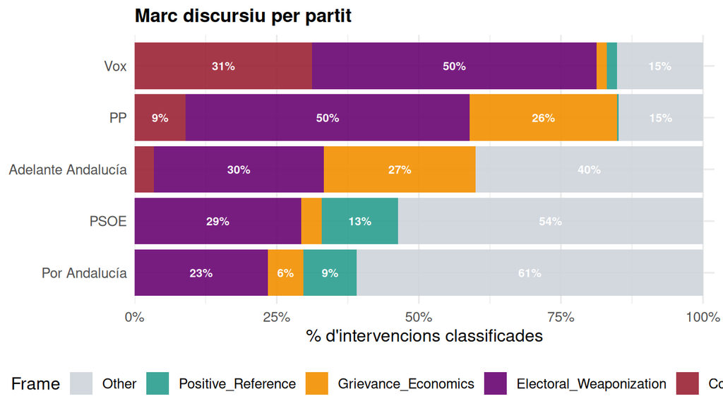

Figure 6: Distribució de frames per partit (% sobre intervencions classificades)

```r
corpus_llm |>
  filter(!is.na(partit)) |>
  count(partit, llm_primary_frame) |>
  group_by(partit) |>
  mutate(pct=100*n/sum(n)) |>
  ungroup() |>
  mutate(
    partit = fct_reorder(
      partit,
      ifelse(llm_primary_frame %in%
               c("Constitutional_Threat","Electoral_Weaponization"), pct, 0),
      .fun=sum, .na_rm=TRUE
    ),
    llm_primary_frame = factor(llm_primary_frame, levels=rev(FRAME_LVLS))
  ) |>
  ggplot(aes(pct, partit, fill=llm_primary_frame)) +
  geom_col(position="stack", alpha=0.9) +
  geom_text(aes(label=if_else(pct>6, paste0(round(pct),"%"), "")),
            position=position_stack(vjust=0.5), size=2.8, color="white", fontface="bold") +
  scale_fill_manual(values=COL_FRAME, name="Frame") +
  scale_x_continuous(labels=label_percent(scale=1),
                     expand=expansion(mult=c(0,0.02))) +
  labs(title="Marc discursiu per partit",
       x="% d'intervencions classificades", y=NULL)
```

### Evolució temporal dels frames per partit

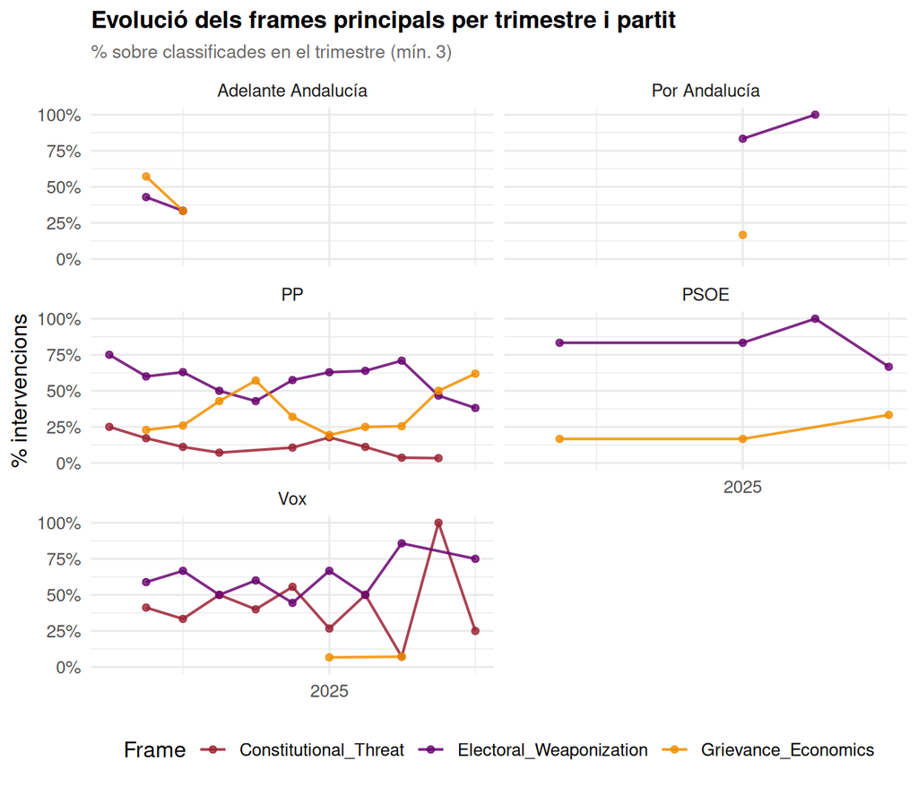

Figure 7: Evolució dels frames principals per trimestre i partit

```r
frames_princ <- c("Constitutional_Threat","Electoral_Weaponization","Grievance_Economics")

corpus_llm |>
  filter(!is.na(partit), !is.na(data_trim),
         llm_primary_frame %in% frames_princ) |>
  count(data_trim, partit, llm_primary_frame) |>
  group_by(data_trim, partit) |>
  mutate(n_tot=sum(n), pct=100*n/n_tot) |>
  ungroup() |>
  filter(n_tot >= 3) |>
  mutate(llm_primary_frame=factor(llm_primary_frame, levels=frames_princ)) |>
  ggplot(aes(data_trim, pct, color=llm_primary_frame)) +
  geom_line(linewidth=0.7, alpha=0.85) +
  geom_point(size=1.5, alpha=0.8) +
  facet_wrap(~partit, ncol=2) +
  scale_color_manual(values=COL_FRAME[frames_princ], name="Frame") +
  scale_x_date(date_breaks="2 years", date_labels="%Y") +
  scale_y_continuous(labels=label_percent(scale=1), limits=c(0,NA)) +
  labs(title="Evolució dels frames principals per trimestre i partit",
       subtitle="% sobre classificades en el trimestre (mín. 3)",
       x=NULL, y="% intervencions")
```

## Part 5: Sentiment × Frame combinats

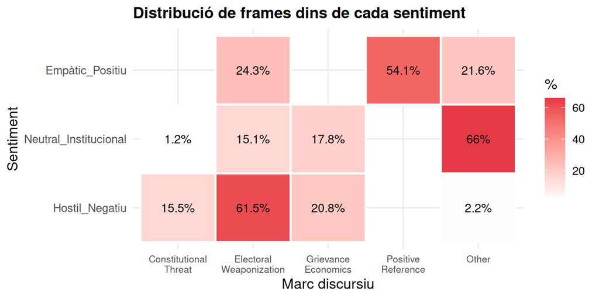

Figure 8: Combinació sentiment × frame — % per fila (sobre el total de cada sentiment)

```r
corpus_llm |>
  count(llm_sentiment_cat, llm_primary_frame) |>
  group_by(llm_sentiment_cat) |>
  mutate(pct=100*n/sum(n)) |>
  ungroup() |>
  mutate(
    llm_sentiment_cat = factor(llm_sentiment_cat,
      levels=c("Hostil_Negatiu","Neutral_Institucional","Empàtic_Positiu")),
    llm_primary_frame = factor(llm_primary_frame, levels=FRAME_LVLS)
  ) |>
  ggplot(aes(llm_primary_frame, llm_sentiment_cat, fill=pct)) +
  geom_tile(color="white", linewidth=0.8) +
  geom_text(aes(label=paste0(round(pct,1),"%")), size=3.5) +
  scale_fill_gradient(low="white", high="#E63946", name="%") +
  scale_x_discrete(labels=\(x) str_replace_all(x,"_","\n")) +
  labs(title="Distribució de frames dins de cada sentiment",
       x="Marc discursiu", y="Sentiment") +
  theme(legend.position="right", axis.text.x=element_text(size=8))
```

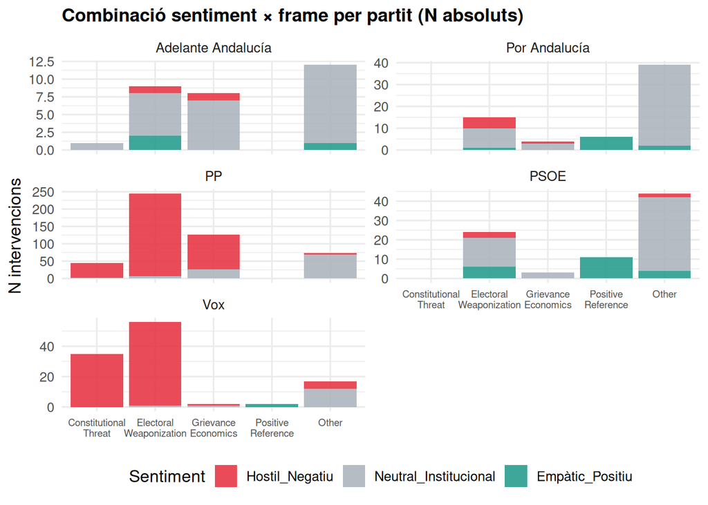

Figure 9: Sentiment × Frame per partit (N absoluts)

```r
corpus_llm |>
  filter(!is.na(partit)) |>
  count(partit, llm_sentiment_cat, llm_primary_frame) |>
  mutate(
    llm_sentiment_cat = factor(llm_sentiment_cat,
      levels=c("Hostil_Negatiu","Neutral_Institucional","Empàtic_Positiu")),
    llm_primary_frame = factor(llm_primary_frame, levels=FRAME_LVLS)
  ) |>
  ggplot(aes(llm_primary_frame, n, fill=llm_sentiment_cat)) +
  geom_col(position="stack", alpha=0.9) +
  facet_wrap(~partit, ncol=2, scales="free_y") +
  scale_fill_manual(values=COL_SENTIMENT, name="Sentiment") +
  scale_x_discrete(labels=\(x) str_wrap(str_replace_all(x,"_"," "), 11)) +
  labs(title="Combinació sentiment × frame per partit (N absoluts)",
       x=NULL, y="N intervencions") +
  theme(axis.text.x=element_text(size=7))
```

## Part 6: Top diputats per mencions classificades

```r
corpus_llm |>
  filter(!is.na(partit)) |>
  group_by(Orador=orador, Partit=partit) |>
  summarise(
    N                    = n(),
    `% Hostil`           = round(100*mean(llm_sentiment_cat=="Hostil_Negatiu"), 1),
    `Frame més freqüent` = names(sort(table(llm_primary_frame), decreasing=TRUE))[1],
    `Conf. mitjana`      = round(mean(llm_confidence, na.rm=TRUE), 2),
    .groups = "drop"
  ) |>
  slice_max(N, n=20) |>
  kable(align=c("l","l","r","r","l","r")) |>
  kable_styling(bootstrap_options=c("striped","hover"),
                full_width=FALSE, position="left")
```

| Orador | Partit | N | % Hostil | Frame més freqüent | Conf. mitjana |
| --- | --- | --- | --- | --- | --- |
| Moreno Bonilla, Juan Manuel | PP | 104 | 76.0 | Electoral_Weaponization | 0.92 |
| España Reina, Carolina | PP | 53 | 86.8 | Electoral_Weaponization | 0.93 |
| Martín Iglesias, Antonio | PP | 25 | 96.0 | Electoral_Weaponization | 0.94 |
| García Sánchez, José Ignacio | Adelante Andalucía | 24 | 8.3 | Other | 0.86 |
| Gavira Florentino, Manuel | Vox | 22 | 86.4 | Electoral_Weaponization | 0.89 |
| Gómez Jurado, José Manuel | Por Andalucía | 18 | 5.6 | Other | 0.90 |
| Gómez Villamandos, José Carlos | PP | 18 | 38.9 | Other | 0.88 |
| Jiménez Jiménez, Cristina Alejandra | Vox | 18 | 100.0 | Electoral_Weaponization | 0.94 |
| López Gabarro, María Dolores | PP | 18 | 100.0 | Grievance_Economics | 0.93 |
| López Olea, Ricardo | Vox | 18 | 100.0 | Electoral_Weaponization | 0.94 |
| Nieto Castro, Inmaculada | Por Andalucía | 18 | 11.1 | Electoral_Weaponization | 0.86 |
| Sanz Cabello, Antonio | PP | 14 | 92.9 | Electoral_Weaponization | 0.94 |
| Venzal Contreras, Pablo José | PP | 14 | 57.1 | Electoral_Weaponization | 0.89 |
| Gómez Corona, Esperanza | Por Andalucía | 13 | 0.0 | Other | 0.92 |
| García García, José Carlos | PP | 11 | 100.0 | Electoral_Weaponization | 0.93 |
| Delgado Ramos, Juan Antonio | Por Andalucía | 10 | 30.0 | Electoral_Weaponization | 0.89 |
| García Román, José Ricardo | PP | 10 | 100.0 | Electoral_Weaponization | 0.92 |
| Jiménez Díaz, Mario Jesús | PSOE | 10 | 0.0 | Electoral_Weaponization | 0.85 |
| Espadas Cejas, Juan | PSOE | 9 | 0.0 | Electoral_Weaponization | 0.87 |
| Morillo Alejo, Benito | Vox | 9 | 100.0 | Constitutional_Threat | 0.89 |
| Saldaña Moreno, Antonio | PP | 9 | 66.7 | Electoral_Weaponization | 0.86 |
| Trujillo Pérez, Jéssica | PP | 9 | 77.8 | Electoral_Weaponization | 0.92 |

## Part 7: Mostres qualitatives per partit

Per a cada partit, es mostren fins a 3 exemples aleatoris que cobreixen **frames i sentiments** el més diversos possible, per il·lustrar la varietat discursiva dins de cada grup parlamentari.

### Adelante Andalucía

**García Sánchez, José Ignacio** · 15/11/2023 [▶](https://videoteca.parlamentodeandalucia.es/watch?id=YmRhNjAwMDQtY2Q2Yy00YTM3LWEzNDktMjcyNzEwYjlhN2Jk&start=33879)

*Diario Sesiones Pleno 055 · Leg. 12*

Empàtic_Positiu Electoral_Weaponization conf. 0.77

L’oradora expressa suport a una “solución democrática” per a Catalunya, defensa el diàleg i el dret a decidir, i rebutja el relat que l’amnistia “rompa España”, cosa que apunta a un to empàtic cap a Catalunya. Tanmateix, el marc central no és Catalunya com a model positiu, sinó la crítica a pactes i concessions del PSOE/PP amb forces catalanes i a l’ús partidista d’aquests acords. Com que l’atac inclou clarament partits nacionals i la seva relació amb actors catalans, encaixa millor amb Electoral_Weaponization; la dimensió econòmica amb Andalusia hi és present però subordinada a la crítica política general.

*[…]* explica porque esa gente son derecho defendiendo educación sanidad vivienda derechos sociales para gente normal y corriente miren señores del PP y de la derecha en general si te quisieran verdaderamente parar la admitía Uche lo tendrían en su mano mañana como vayan al Congreso los diputados tengan sé yo si no tienen que pactar con la investidura con los independentistas catalanes que nace de la investidura directamente al señor Sánchez sabe por qué no lo hacen porque en realidad gente lista dentro de su fila hay gente que está dando vuelta coco alguno son diputados y diputadas y saben que ni se rompe España ni un golpe de Shawn y sacaba la democracia ni sacaba dicho derecho ni se mapa *[…]*

**García Sánchez, José Ignacio** · 15/11/2023 [▶](https://videoteca.parlamentodeandalucia.es/watch?id=YmRhNjAwMDQtY2Q2Yy00YTM3LWEzNDktMjcyNzEwYjlhN2Jk&start=14754)

*Diario Sesiones Pleno 055 · Leg. 12*

Neutral_Institucional Grievance_Economics conf. 0.88

L’extracte rebutja explícitament el relat alarmista sobre Catalunya (‘ni España se rompe’), així que no encaixa en Constitutional_Threat. El nucli és que els acords amb l’‘élite catalana’ acaben perjudicant Andalusia en finançament, inversió i serveis, amb comparació directa amb Andalusia; per tant predomina el greuge econòmic. El to és crític però no usa llenguatge pejoratiu extrem ni agressiu contra Catalunya, de manera que és més aviat institucional-crític.

*[…]* de julio miré seamos serio iba en un poco el tono ni España se rompe y hay un golpe de sábado y el fin de la Democracia luche lo sabe perfectamente igual que yo aquí esta modalidad volviendo un capítulo anterior un capítulo que en realidad conocido por todos y todas el para el capítulo se llama que la élite catalana se integran en la normalidad vuelven al redil y a cambio de un acuerdo por el cual al final siempre acabo perdiendo lo andaluz y andaluza esto se traduce en que tenemos menos financiación que tenemos menos inversión que tenemos menos y peores infraestructuras que tenemos menos y peor servicio público que tenemos una economía más dependiente y que tenemos *[…]*

**García Sánchez, José Ignacio** · 15/11/2023 [▶](https://videoteca.parlamentodeandalucia.es/watch?id=YmRhNjAwMDQtY2Q2Yy00YTM3LWEzNDktMjcyNzEwYjlhN2Jk&start=15191)

*Diario Sesiones Pleno 055 · Leg. 12*

Hostil_Negatiu Grievance_Economics conf. 0.83

L’extracte critica un “acuerdo con la élite catalana” perquè perjudica Andalusia i contraposa explícitament els interessos andalusos als avantatges per a Catalunya, de manera que encaixa en el greuge econòmic. Tot i el to dur, no presenta Catalunya principalment com una amenaça constitucional, sinó com a part d’un repartiment injust per a Andalusia. També hi ha atac al PSOE/PP, però el nucli del fragment se centra més en el finançament i el perjudici comparatiu a Andalusia.

*[…]* Belloch convenció de que hay millones de andaluces y andaluzas pero millones dando luz andaluza y que tan horrorizado con la panda de machito facilite Rafita que se ponen a acosar a la sede del PSOE en estos días pero qué le cabrea que pa que no tengan que gobierna esa gentuza que llamo aguanta un acuerdo con la élite catalana que nos perjudica lo andaluz y andaluza y mire que Cataluña quiere un buen modelo de financiación y Andalucía cuando que Cataluña quiere hechos ocho N Me parece bien Andalucía pa cuando otro territorio avancen en derecho bueno p Andalucía si nosotros creemos que eso nos abre puertas en el avance derecho pero que los platos rotos la investidura no *[…]*

### Por Andalucía

**Nieto Castro, Inmaculada** · 15/11/2023 [▶](https://videoteca.parlamentodeandalucia.es/watch?id=YmRhNjAwMDQtY2Q2Yy00YTM3LWEzNDktMjcyNzEwYjlhN2Jk&start=34375)

*Diario Sesiones Pleno 055 · Leg. 12*

Empàtic_Positiu Electoral_Weaponization conf. 0.91

L’extracte defensa explícitament el diàleg amb Catalunya i critica el discurs d’‘a por ellos’, presentant-lo com a generador de crispació i d’independentisme. No hi ha una amenaça atribuïda a Catalunya, sinó un atac a Vox i a la dreta per instrumentalitzar la qüestió catalana amb fins partidistes. Com que la menció a Catalunya serveix principalment per desacreditar l’estratègia d’un partit nacional rival, el frame dominant és d’ús electoral de la qüestió catalana.

*[…]* que tergiversar la realidad e insultar gratuitamente ustedes consideran que eso tiene un rédito pero creo que no lo tiene que uno tiene de hecho en absoluto a que cómodo carril e para a analizar la situación y para ver qué pasa y a por ello ya lo hemos explorado en la Por ello en la redacción del Estado con Cataluña fue una fábrica de independentistas de crispación social de problema económico de tensión e en la por ello o me exactamente cuál fue el beneficio que nos trajo como país de hecho qué sentido tiene invocar a la patria y en nombre de la patria ir a por ellos a una por una parte de nuestro compatriota ninguno no tiene *[…]*

**Gómez Jurado, José Manuel** · 15/11/2023 [▶](https://videoteca.parlamentodeandalucia.es/watch?id=YmRhNjAwMDQtY2Q2Yy00YTM3LWEzNDktMjcyNzEwYjlhN2Jk&start=5041)

*Diario Sesiones Pleno 055 · Leg. 12*

Neutral_Institucional Other conf. 0.91

La menció a Catalunya apareix com a retret procedimental: es critica que altres portaveus desviïn el debat parlant de ‘Cataluña y el País Vasco’ en lloc de la moció sobre persones grans. No hi ha llenguatge hostil cap a Catalunya ni es presenta com a amenaça constitucional, tampoc hi ha comparació econòmica amb Andalusia ni ús clar per atacar un partit nacional pel seu pacte amb partits catalans. Per tant, la referència és accessòria i fora dels marcs principals.

gracias señor presidente vamos a ir por partes En primer lugar a la portavoz de vox mucho tono grandilocuente donde no hay mata no hay patata que qué decía mi abuela no aceptamos la enmienda de votos que se ha tirado que ha dedicado su intervención habla de Cataluña hombre que nos acusa a nosotros no trabaja viniendo con el argumentario estatal y no hablando absolutamente nada de lo que dice la moción Hombre como pa que pa que se le si se mira en el Partido Popular digo por empresa por parte a mi primo la enmienda diecisiete las dieciséis y la catorce el resto que ahora las *[…]*

**Gómez Jurado, José Manuel** · 18/12/2025 [▶](https://videoteca.parlamentodeandalucia.es/watch?id=OThhZGI5ZjgtNDcwZS00OTMyLTgzMDgtNDBhNTc0NjY1OWU1&start=4161)

*Diario Sesiones Pleno 145 · Leg. 12*

Empàtic_Positiu Positive_Reference conf. 0.94

La menció a Catalunya apareix en una comparativa de política pública: s’assenyala que a Catalunya hi ha 14 Barnahus i a Andalusia cap. Això presenta Catalunya com a referent de bona pràctica, no com a amenaça ni com a actor d’un atac partidista estatal. Tot i que hi ha molta crítica dura al PP, aquesta crítica no va dirigida a Catalunya ni usa partits catalans com a arma electoral.

*[…]* jurídica gratuita para aquellas personas que están en situación de vulnerabilidad, en situación de riesgo de exclusión social, la creación de centros de internamiento de menores. No sé si todas estas cuestiones no han tenido a bien. Y otra de las cuestiones que a nosotros nos parecía más importante, digo por aquella comparativa que están todo el rato haciéndose con Cataluña, que son las barnajús. Para quienes no sepan lo que son, son aquellas casas locales o locales o en definitiva sitios adaptados para aquellos menores que han sido víctimas de algún tipo de violencia sexual y que en Cataluña hay 14 y en Andalucía ninguna. Tampoco se ha tenido a bien ni siquiera discutirlo. Aumentos de psicólogos, de pedagogos, de *[…]*

### PP

**Gómez Villamandos, José Carlos** · 15/11/2023 [▶](https://videoteca.parlamentodeandalucia.es/watch?id=YmRhNjAwMDQtY2Q2Yy00YTM3LWEzNDktMjcyNzEwYjlhN2Jk&start=384)

*Diario Sesiones Pleno 055 · Leg. 12*

Neutral_Institucional Other conf. 0.97

La menció a Catalunya és incidental i descriptiva: s’assenyala una excepció regulatòria (‘amb l’excepció de Catalunya i País Basc’) dins d’una explicació tècnica sobre la LOSU i l’adaptació normativa andalusa. No hi ha llenguatge pejoratiu ni cap comparació de greuge amb Andalusia, tampoc una amenaça constitucional ni ús partidista contra un partit nacional. Per tant, el to és institucional i el frame no encaixa en les categories substantives excepte ‘Other’.

*[…]* en concreto Lalo su señala la nueva figura de los profesores permanente laborales de una forma genérica y a pesar de lo intentó de legislador de equiparar figura equivalente la comunidade autónoma con objeto de acceder a la categoría de profesor permanente laboral lo cierto es que en Andalucía y en el resto de comunidades autónomas con la excepción de Cataluña y País Vasco está preu esta figura necesitan de una regulación normativa urgente dado esa inseguridad jurídica que se ha generado como consecuencia de la regulación producida por la los por ello imprescindible adaptar la Ley Andaluza de Universidades y en concreto su artículo cuarenta en nuestro ámbito competencial la lau como le digo en el apartado uno del artículo *[…]*

**Moreno Bonilla, Juan Manuel** · 26/06/2025 [▶](https://videoteca.parlamentodeandalucia.es/watch?id=MzU2Y2E0N2YtYjYyNi00ODE0LTljZWEtNjliOTgyMjk4OTUy&start=15825)

*Diario Sesiones Pleno 124 · Leg. 12*

Empàtic_Positiu Other conf. 0.95

La menció a Catalunya és circumstancial i funerària: expressa condol per la mort d’una delegada de la Junta a Catalunya, sense cap valoració política sobre Catalunya ni les seves institucions. La resta del fragment se centra en corrupció i gestió pressupostària a Andalusia i el PSOE, però no articula Catalunya com a amenaça, greuge comparatiu, arma electoral vinculada a partits catalans, ni model positiu. Per les regles d’exclusió, la referència catalana no activa cap frame específic.

presidente muchas gracias señor Martín me van a permitir ustedes que antes de comenzar la intervención para contestar al señor Martín traslade en nombre del gobierno nuestra tristeza por el fallecimiento de la delegada del gobierno de la Junta de Andalucía en Cataluña la señora Esperanza García que desgraciadamente falleció a muy corta de la semana pasada y de aquí le trasladamos pues todo nuestro cariño a su familia a sus amigos y sobre todo también el agradecimiento por el enorme esfuerzo compromiso y trabajo que ha realizado a lo largo de ese escaso año en el que ha podido ostentar al nivel *[…]*

**Gómez Villamandos, José Carlos** · 24/09/2025 [▶](https://videoteca.parlamentodeandalucia.es/watch?id=NGVjODM2YWEtMDVhOS00YWQzLTlkYzYtMGYyNGM5ZTY0NGUy&start=12823)

*Diario Sesiones Pleno 131 · Leg. 12*

Empàtic_Positiu Positive_Reference conf. 0.73

La menció a Catalunya apareix en dos usos: com a comparació acadèmica positiva amb la Politécnica de Cataluña i com a destinació laboral dels joves andalusos. No hi ha llenguatge hostil cap a Catalunya ni una amenaça constitucional; tampoc un atac electoral basat en pactes amb partits catalans. La referència més substantiva és la de Catalunya com a estàndard universitari de prestigi, així que predomina el marc positiu.

*[…]* tú pagas a las propias universidades, eso ya creo que es el colmo del cinismo por parte de este Gobierno. Mire, lo que ha pasado con ACUA le puedo garantizar, además se lo garantizo, que no hubiera pasado si en vez de suceder esto, que podría haber sucedido exactamente igual y seguro que ha sucedido, hubiera sido con la agencia catalana o con la agencia vasca. Seguro que ahí el Gobierno de Sánchez no se había atrevido a modificar un informe, seguro que no, un informe hecho por las tasagencias. Y lo que pasa es que la coyuntura era la coyuntura, me decían ustedes, ¿y el por qué el Ministerio sí lo ha hecho? Pues porque estamos en un año electoral *[…]*

### PSOE

**Torres Caballero, Víctor Manuel** · 20/02/2025 [▶](https://videoteca.parlamentodeandalucia.es/watch?id=NzU4MTE4OTItMzhkYy00ZjFlLTk3MDItMTY4Y2MxMmZmNjM0&start=23227)

*Diario Sesiones Pleno 107 · Leg. 12*

Hostil_Negatiu Other conf. 0.73

L’extracte esmenta partits qualificats d’“independentista”, però la referència a Catalunya no estructura l’argument central, que és un atac al PP per la política municipal i la moció de censura de Jaén. No hi ha comparació econòmica amb Catalunya ni una presentació de Catalunya com a amenaça constitucional general. Tampoc hi ha ús clar de pactes amb partits catalans per atacar un partit nacional en clau estatal; la menció és accessòria i local.

*[…]* el Ayuntamiento de Jaén para ser presidente de la Diputación. Y lo que hizo fue debatir con un taburete al señor Domínguez. Y luego no cogió ni siquiera el acta de diputado provincial, pero fue concejal del Ayuntamiento de Jaén. Y abandonó el barco cuando vio que venía una moción de censura, porque ese partido que usted ha dicho aquí, independentista, y que no seré yo quien defienda, es el mismo partido con el que ustedes gobiernan en Baeza, en Santiago Pontones o en Santisteban del Puerto. Señora mestre, usted es que gobierna en municipios de Jaén compartidos a los que usted ha llamado independentistas. Por cierto, también lo será en todos ustedes que es de Cádiz, la línea 100%, ¿no?, *[…]*

**Murillo López, Alicia** · 05/03/2025 [▶](https://videoteca.parlamentodeandalucia.es/watch?id=MmMwMzM2NjItN2U5NC00MDk4LTk3MTItYTQ5ODE3YTVkYmZl&start=10077)

*Diario Sesiones Pleno 109 · Leg. 12*

Hostil_Negatiu Electoral_Weaponization conf. 0.80

L’extracte menciona Catalunya sobretot en el marc d’un atac al PP i a Feijóo: es denuncia que rebutgen la quita perquè ‘cuando se lo dan a Cataluña’ ho utilitzen políticament. No presenta Catalunya com una amenaça constitucional ni com un model positiu, i tampoc activa Grievance_Economics perquè no es diu que Andalusia perdi per privilegis catalans, sinó que es critica l’ús partidista d’aquesta comparació. El to cap a la catalanofòbia i l’estratègia política associada és clarament valoratiu i combatiu.

*[…]* 15 meses dijo que aceptaría la quita de deuda si llegaba a 17 .000 millones de euros ay ha llegado a casi 19 .000 millones de euros ¿y ahora qué? ¿y ahora qué? ¿y ahora qué? mire tiene que ser duro decir ahora que no solamente porque se lo pide el señor Feijóo porque claro cuando se lo dan a Cataluña resulta que esto es lo peor del mundo pero cuando Andalucía es la comunidad más beneficiada resulta que esto no sirve para nada fíjese a dónde le ha llevado la ruindad de su partido que el otro día se levantaron del Consejo de Política Fiscal para evitar la foto para evitar la foto votando en contra de que a Andalucía *[…]*

**Férriz Gómez, María de los Ángeles** · 27/06/2024 [▶](https://videoteca.parlamentodeandalucia.es/watch?id=NGZiMmVhYzctNGMxMy00MzQ0LTgzZmEtNWRmYzI2MWY4ZjJl&start=29424)

*Diario Sesiones Pleno 083 · Leg. 12*

Neutral_Institucional Other conf. 0.95

L’extracte només recull una denúncia d’insults rebuts en el ple i no conté una menció substantiva a Catalunya ni a institucions catalanes. Tot i aparèixer el terme «golpista», no s’atribueix a Catalunya ni s’articula cap marc sobre unitat d’Espanya, greuge econòmic o pactes amb partits catalans. Per tant, correspon una classificació residual i neutral.

presidente. Yo quiero que conste en acta que este grupo no ha habido. Yo quiero también denunciar que este grupo, y no se ha parado el pleno, ha recibido insultos como sátrapa, golpista, mariachis, etcétera, etcétera, etcétera.

### Vox

**Sevilla Rodríguez, Antonio** · 14/12/2023 [▶](https://videoteca.parlamentodeandalucia.es/watch?id=MWY4MjZjNDYtMDJkOC00Y2U4LThlZjctMjhiZjdkZjYxNjFk&start=28149)

*Diario Sesiones Pleno 060 · Leg. 12*

Neutral_Institucional Electoral_Weaponization conf. 0.69

La menció a Catalunya és instrumental i se centra en atacar una llei estatal i, per extensió, el Govern central i l’esquerra, no en presentar Catalunya com una amenaça constitucional. El passatge sobre Catalunya és empíric-descriptiu (‘se ha demostrado… en Cataluña’) i serveix com a exemple de fracàs regulatori, sense llenguatge pejoratiu específic contra Catalunya. Com que no hi ha comparació econòmica amb Andalusia ni un model positiu, i l’atac principal s’adreça a actors polítics nacionals, el frame dominant és d’ús electoral-partidista.

*[…]* ley dirigida a garantizar el acceso a vivienda no puede sustentar se en medida de injerencia la propia del sector privado y su relación jurídica el problema existente actualmente en el mercado inmobiliario está relacionado con la oferta de vivienda sin embargo la medida establecida reducen el Esto de inmueble tal y como se ha demostrado a nivel nacional en Cataluña y a nivel internacional en Alemania y afectan fundamentalmente a la demanda imitación de precio prorrogado obligatorio contrato entre o efecto pueden verse claramente la subida del precio medio del metro cuadrado se ha disparado un seis coma noventa y cuatro por ciento entre noviembre de dos mil veintidós y dos mil veintitrés en buen inmueble para Renta no ayuda *[…]*

**Gavira Florentino, Manuel** · 25/10/2023 [▶](https://videoteca.parlamentodeandalucia.es/watch?id=YTVlYjY1ZTItZTllZi00NGEyLTg5YmEtN2Y2MzJiMzk5MWVj&start=5821)

*Diario Sesiones Pleno 053 · Leg. 12*

Neutral_Institucional Other conf. 0.80

L’extracte menciona «lo vasco y de los catalanes» de manera tangencial i sense llenguatge pejoratiu específic contra Catalunya ni les seves institucions. El focus és l’atac al PP, al PSOE i a la situació social d’Andalusia, no una amenaça constitucional ni una comparació econòmica directa amb Catalunya. Tampoc es presenta Catalunya com a model positiu ni com a actor clau d’un pacte concret per atacar un partit nacional.

presidente señorías Bueno señores no nos guste escuchaba tabla de lo vasco y de los catalanes bienvenido al autónomo sé que le guste tanto y esto pasa con el Partido Popular y con el Partido Socialista en el Gobierno no sé de qué se extrañan y aguarda y aguarda mientras Costa está centrado en el debate nacional mucha agenda Madrid toda la semana tiene algo y lo que es peor con la cabeza en otro lado *[…]*

**Ruiz Vázquez, Ana María** · 26/02/2026 [▶](https://videoteca.parlamentodeandalucia.es/watch?id=MjZjYjUyMzAtNGQ2Ny00MTJmLTk1ZGItNzIwYTYzMjY5MDUy&start=18473)

*Diario Sesiones Pleno 150 · Leg. 12*

Hostil_Negatiu Constitutional_Threat conf. 0.67

L’extracte usa Catalunya com a dada alarmista dins un discurs de forta càrrega negativa sobre delinqüència i immigració. No hi ha comparació econòmica amb Andalusia per finançament ni atac a un partit nacional per pactes amb partits catalans. Tampoc es presenta Catalunya com a model positiu; la menció encaixa millor com a amenaça/alarma social vinculada a l’ordre i la cohesió.

*[…]* Socialista, consejera, políticas fallidas, fracasadas, que no protegen a la mujer. Al revés. Mire, en España en los últimos diez años las violaciones se han disparado un 288%. Han pasado de 1 .382 en 2017 a 5 .363 en 2025, según mi interior. Los delitos contra la libertad sexual han pasado de 11 .692 a 21 .659, el doble. En Cataluña las agresiones sexuales con penetración se han disparado un 2 .200%. Ahora me podrá contar usted aquí lo que quiera, pero nosotros le traemos datos de vidas muy duras de mujeres a las que sus políticas no protegen. En 2025 Andalucía fue la comunidad autónoma con más feminicidio el 30 % frente a nacional y en cuanto a los agresores *[…]*